# Time Series: A First Course with Bootstrap Starter

# Lesson 10-12: Imputation and Signal Extraction

- By forecasting and backcasting, we can extend a time series and then apply filters.

## Remark 10.12.4. Extending a Time Series Sample

- Recall from Remark 3.1.7 that applying a moving average filter leaves out the beginning and end of the sample.
- We can extend a time series via forecasts and backcasts, and then apply the filter to fix this problem.
- If the symmetric filter is of length $2m+1$, we need $m$ forecasts and $m$ backcasts.

## Proposition 10.12.6

- Suppose a filter $\Psi (B)$ is applied to $\{ X_t \}$, yielding $\{ Y_t \}$.
- Given the sample $\underline{X}_n$, for any time $t$
  $${\mathbb E} [ Y_t \vert \underline{X}_n ] =
  \sum_{j = - \infty}^{\infty} \psi_j \, {\mathbb E} [ X_{t-j } \vert
  \underline{X}_n ].$$
- This justifies extending a series: we filter the sample $\underline{X}_n$ extended to points $t > n$ and $t < 1$ via appending forecast and backcasts.

## Example 10.12.8. HP Trend of West Starts Annual Rate

- We consider the annual growth rate of the West Housing Starts data.
- We apply the Hodrick-Prescott (HP) filter.
- First, we will fit an MA(12) model.

```r
polymul <- function(a,b)
{
    bb <- c(b,rep(0,length(a)-1))
    B <- toeplitz(bb)
    B[lower.tri(B)] <- 0
    aa <- rev(c(a,rep(0,length(b)-1)))
    prod <- B %*% matrix(aa,length(aa),1)
    return(rev(prod[,1]))
}

ARMAauto <- function(phi,theta,maxlag)
{
    p <- length(phi)
    q <- length(theta)
    gamMA <- polymul(c(1,theta),rev(c(1,theta)))
    gamMA <- gamMA[(q+1):(2*q+1)]
    if (p > 0)
    {
        Amat <- matrix(0,nrow=(p+1),ncol=(2*p+1))
        for(i in 1:(p+1))
        {
            Amat[i,i:(i+p)] <- c(-1*rev(phi),1)
        }
        Amat <- cbind(Amat[,(p+1)],as.matrix(Amat[,(p+2):(2*p+1)]) +
            t(matrix(apply(t(matrix(Amat[,1:p],p+1,p)),2,rev),p,p+1)))
        Bmat <- matrix(0,nrow=(q+1),ncol=(p+q+1))
        for(i in 1:(q+1))
        {
            Bmat[i,i:(i+p)] <- c(-1*rev(phi),1)
        }
        Bmat <- t(matrix(apply(t(Bmat),2,rev),p+q+1,q+1))
        Bmat <- matrix(apply(Bmat,2,rev),q+1,p+q+1)
        Bmat <- Bmat[,1:(q+1)]
        Binv <- solve(Bmat)
        gamMix <- Binv %*% gamMA
        if (p <= q) { gamMix <- matrix(gamMix[1:(p+1),],p+1,1)
            } else gamMix <- matrix(c(gamMix,rep(0,(p-q))),p+1,1)
        gamARMA <- solve(Amat) %*% gamMix
    } else gamARMA <- gamMA[1]

    gamMA <- as.vector(gamMA)
    if (maxlag <= q) gamMA <- gamMA[1:(maxlag+1)] else gamMA <- c(gamMA,rep(0,(maxlag-q)))
    gamARMA <- as.vector(gamARMA)
    if (maxlag <= p) gamARMA <- gamARMA[1:(maxlag+1)] else {
    for(k in 1:(maxlag-p))
    {
        len <- length(gamARMA)
        acf <- gamMA[p+1+k]
        if (p > 0) acf <- acf + sum(phi*rev(gamARMA[(len-p+1):len]))
        gamARMA <- c(gamARMA,acf)
    } }
    return(gamARMA)
}

Wstarts <- read.table("Wstarts.b1",header=TRUE,skip=2)[,2]
Wstarts <- ts(Wstarts,start = 1964,frequency=12)
west <- diff(log(Wstarts),lag=12)
n <- length(west)
gamma.hat <- acf(west,lag=n-1,type="covariance",plot=FALSE)$acf[,,1]
q <- 12

gausslik.maq <- function(theta,data,fit.flag)
{
    n <- length(data)
    gamma.maq <- ARMAauto(NULL,theta,n)
    kappa.vec <- gamma.maq[2]/gamma.maq[1]
    varphi.vec <- kappa.vec
    quad.new <- 0
    quads <- NULL
    ldet <- 0
    ldets <- NULL
    eps <- NULL

    for(k in 2:n)
    {
        schur.new <- gamma.maq[1] - t(varphi.vec) %*% rev(gamma.maq[2:k])
        eps.new <- data[k] - t(varphi.vec) %*% data[1:(k-1)]
        eps <- c(eps,eps.new)
        quad.new <- quad.new + eps.new^2/schur.new
        quads <- c(quads,quad.new)
        ldet <- ldet + log(schur.new)
        ldets <- c(ldets,ldet)
        kappa.new <- (gamma.maq[k+1] - sum(varphi.vec*gamma.maq[2:k]))/schur.new
        kappa.new <- kappa.new[1,1]
        if(abs(kappa.new) < 10^(-15)) kappa.new <- 0
        kappa.vec <- c(kappa.vec,kappa.new)
        varphi.vec <- rev(varphi.vec) - kappa.new * varphi.vec
        varphi.vec <- rev(c(varphi.vec,kappa.new))
    }
    gauss.lik <- n*(1 + log(2*pi)) + n*log(quads[n-1]/n) + ldets[n-1]

    if(fit.flag) { return(gauss.lik) } else
    {
        return(list(quads[n-1]/n,eps))
    }
}
```

- Because the fitting takes some time, we instead input the MLE directly below (based on a prior run).

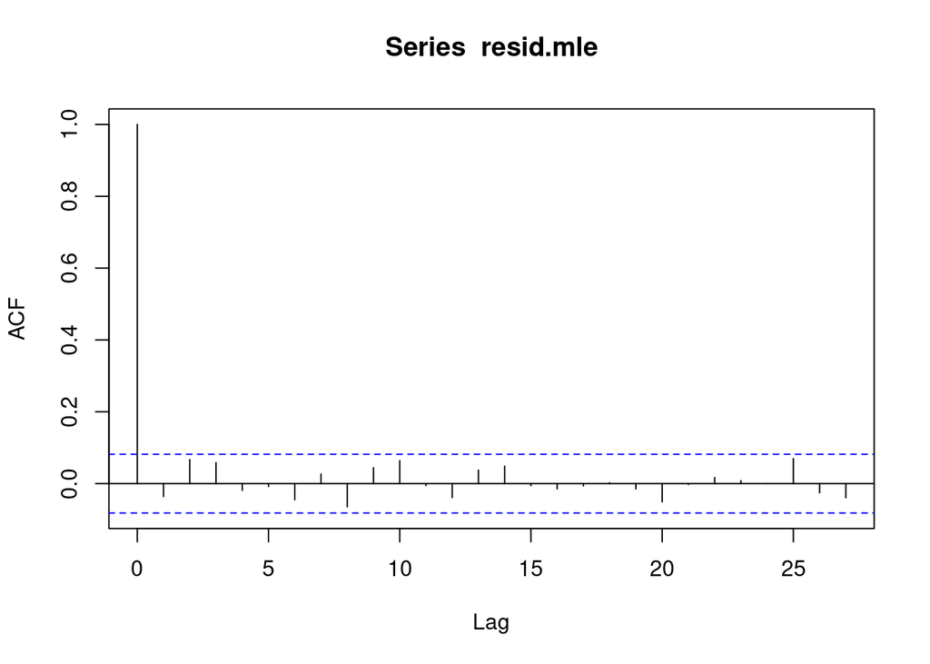

```r
theta.mle <- c(0.651972958905815, 0.652200820985369, 0.627422633499361, 0.646525805480097,
0.625424457604761, 0.644635978951906, 0.637430978594635, 0.635720014729216,
0.625268961947794, 0.634947219500035, 0.600750521900405, -0.367624464655481
)
sig2.mle <- gausslik.maq(theta.mle,west,fit.flag=FALSE)[[1]]
resid.mle <- gausslik.maq(theta.mle,west,fit.flag=FALSE)[[2]]
acf(resid.mle)
```

- The ACF of the residuals indicates this model fit seems adequate.
- Next, we obtain an invertible form of the moving average polynomial by root flipping.

```r
theta.poly <- c(1,theta.mle)
new.poly <- 1
sig2.new <- sig2.mle
ma.roots <- polyroot(theta.poly)
for(i in 1:q)
{
    if(Mod(ma.roots[i]) < 1)
    {
        ma.roots[i] <- 1/ma.roots[i]
        sig2.new <- sig2.new*(1/ma.roots[i]^2)
    }
    new.poly <- polymul(new.poly,c(1,-1/ma.roots[i]))
}
new.poly <- Re(new.poly)
sig2.new <- Re(sig2.new)
theta.inv <- new.poly[-1]
```

- Then we extend the time series with forecasts and backcasts.
- We go $100$ steps forwards and backwards.

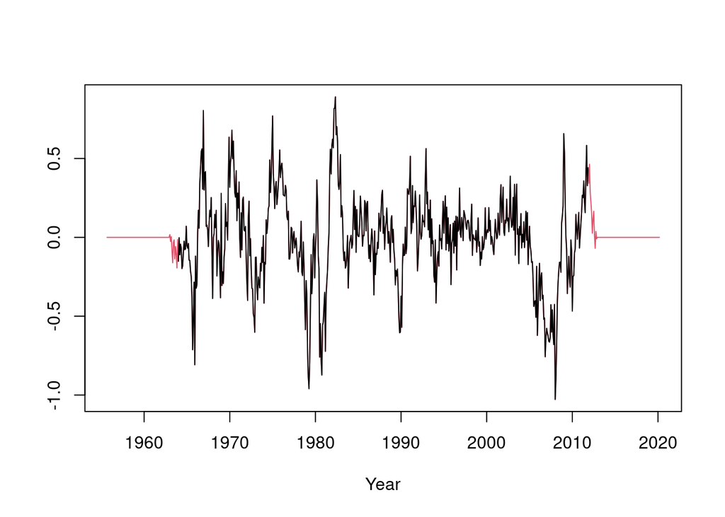

```r
H <- 100
T <- n+2*H
gamma <- ARMAauto(NULL,theta.inv,T)*sig2.new
x <- c(rep(NA,H),west,rep(NA,H))
x.fore <- c(west,rep(NA,H))
T <- n+H
kappa.vec <- gamma[2]/gamma[1]
varphi.vec <- kappa.vec
for(k in 2:(T-1))
{
    schur.new <- gamma[1] - t(varphi.vec) %*% rev(gamma[2:k])
    kappa.new <- (gamma[k+1] - sum(varphi.vec*gamma[2:k]))/schur.new
    kappa.new <- kappa.new[1,1]
    if(abs(kappa.new) < 10^(-15)) kappa.new <- 0
    kappa.vec <- c(kappa.vec,kappa.new)
    varphi.vec <- rev(varphi.vec) - kappa.new * varphi.vec
    varphi.vec <- rev(c(varphi.vec,kappa.new))
    cast <- sum(varphi.vec * x.fore[1:k])
    if(k >= n) x.fore[k+1] <- cast
}
x.aft <- rev(c(rep(NA,H),x.fore))
T <- n+2*H
kappa.vec <- gamma[2]/gamma[1]
varphi.vec <- kappa.vec
for(k in 2:(T-1))
{
    schur.new <- gamma[1] - t(varphi.vec) %*% rev(gamma[2:k])
    kappa.new <- (gamma[k+1] - sum(varphi.vec*gamma[2:k]))/schur.new
    kappa.new <- kappa.new[1,1]
    if(abs(kappa.new) < 10^(-15)) kappa.new <- 0
    kappa.vec <- c(kappa.vec,kappa.new)
    varphi.vec <- rev(varphi.vec) - kappa.new * varphi.vec
    varphi.vec <- rev(c(varphi.vec,kappa.new))
    cast <- sum(varphi.vec * x.aft[1:k])
    if(k >= n+H) x.aft[k+1] <- cast
}
x.cast <- rev(x.aft)
x.ext <- ts(x.cast,start=(1964-H/12),frequency=12)
plot(x.ext,col=2,ylab="",xlab="Year")
lines(ts(x,start=(1964-H/12),frequency=12))
```

- Then we filter the extended data.
- We use the HP filter with parameter $1/1600$. This uses an exact formula for the filter (Exercise 6.29 in the book).

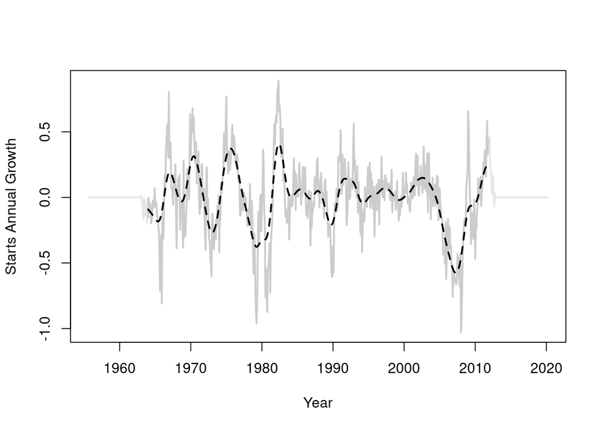

```r
q <- 1/1600
s <- (2*q + 2*q^(1/2)*(q+16)^(1/2))^(1/2)
r <- (q^(1/2) + (q+16)^(1/2) + s)/4
c <- q/r^2
phi1 <- 2*(q^(1/2)-(q+16)^(1/2))/(4*r)
phi2 <- (q^(1/2)+(q+16)^(1/2) - s)/(4*r)
theta <- atan(s/4)
lags <- seq(0,H)
psi <- 2*c*r^(4-lags)*sin(theta)*(r^2*sin(theta*(1+lags)) - sin(theta*(lags-1)))
psi <- psi/((1-2*r^2*cos(2*theta)+r^4)*(r^2-1)*(1-cos(2*theta)))
psi <- c(rev(psi),psi[-1])
west.trend <- filter(x.ext,psi,method="convolution")[(H+1):(length(x.ext)-H)]
west.trend <- ts(west.trend,start=1964,frequency=12)

plot(x.ext,lwd=2,col=grey(.9),xlab="Year",ylab="Starts Annual Growth")
lines(ts(c(rep(NA,H),west,rep(NA,H)),start=1964-H/12,frequency=12),lwd=2,col=grey(.8))
lines(west.trend,col=1,lwd=2,lty=2)
```